# 01_introduction

Tobias Gerstenberg

# Pace

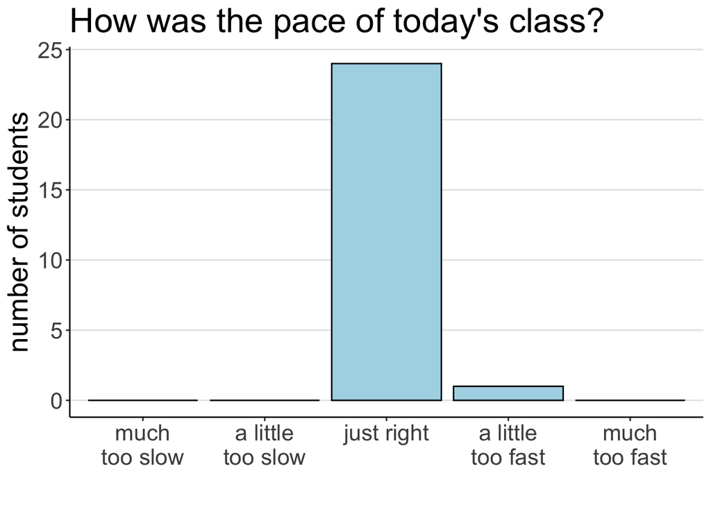

# Happiness

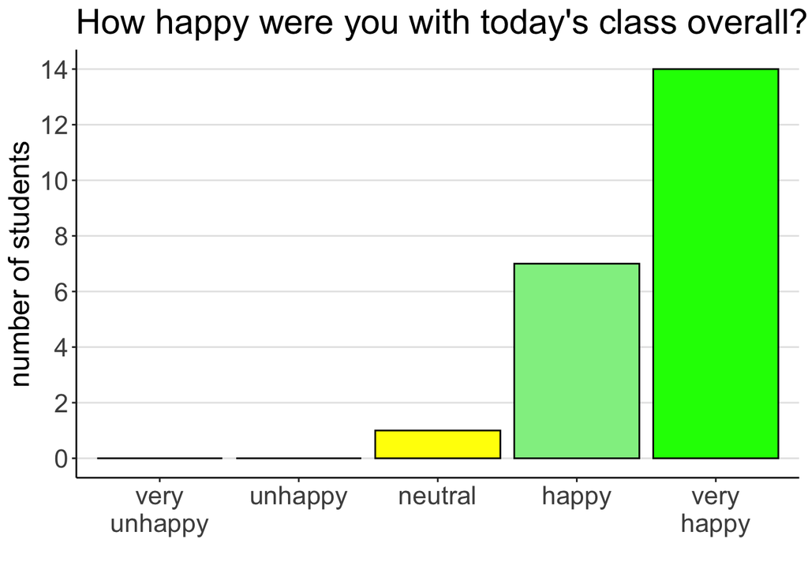

# What did you like? What can be improved?

> First half with Nilam was slower, and second half with Tobi went a little too quickly (had to pull up the slides and backread to understand course logistics)

> I liked that we had a glimpse about the whole course. I’d like to perhaps add a bit of content to the first class so people understand better what the class look like.

> I appreciated the humor, and the deep overview of class expectations. I would like for next class to mention the possible topics of data & projects we’ll be working on. For ex: I’m a qualitative researcher, and don’t even know yet how to formulate a research question with quantitative data in mind. Thinking about the final project is daunting since I don’t even know what topics I could use for that project. Briefly discussing strategies to deal with this would be super helpful!

> The pace was right and I liked the mix of humor and good music!

|  | Response |
| --- | --- |
| 1 | This was a very encouraging introduction to the class. I really appreciated the breakdown of teaching goals, tools to be used, and course expectations (time commitment, etc.). |
| 2 | I wouldn't change anything |
| 3 | I liked how you clearly stated the reasons for why R is still relevant as opposed to switching everything to python |
| 4 | IT'S AMAZING |
| 5 | I liked how we received a comprehensive overview of what we will learn in this class. I don't have any suggestions for improvement right now! |
| 6 | I liked that expectations and course assignments were clearly stated. Can't think of anything that can be improved. |
| 7 | First half with Nilam was slower, and second half with Tobi went a little too quickly (had to pull up the slides and backread to understand course logistics) |
| 8 | Thank you for your positive attitude :) was having a bad day but this class really brighten my mood |
| 9 | I think today's class provided us with a great overview with what to expect in this class, what is expected of us, and what we are going to learn. It got me very excited for this class! |
| 10 | I liked that we had a glimpse about the whole course. I'd like to perhaps add a bit of content to the first class so people understand better what the class look like. |

[output cut: 13 more lines]

# What to do next time

- consider adding some more content examples to the first class